# Introduction to Metamorphism and Metamorphic Rocks

Dr. Ahmad Redaa

2024-09-25

# What is Metamorphism?

- **Metamorphism**: Process where rocks undergo changes in mineralogy, texture, and chemical composition due to changing physical and chemical conditions.
- Occurs predominantly in the **solid state**.
- **Diagenesis vs. Metamorphism**: Diagenesis occurs near Earth’s surface, while metamorphism occurs at greater depths.
- **Greek Origin**: Meta (change) + Morph (form).

# Questions

1. What is metamorphism?
2. How does it differ from diagenesis and igneous processes?
3. What are the main agents controlling metamorphism?
4. How does strain affect metamorphic rocks?
5. How do we recognize precursor rocks (protoliths)?
6. What are metamorphic field gradients?

# Limits of Metamorphism

- **Low-Temperature Boundary**: Transition from diagenesis, marked by the formation of minerals like laumontite `Ca(Al₂Si₄O₁₂)·4H₂O` and prehnite `Ca₂Al(AlSi₃O₁₀)(OH)₂` as they form at **100°C to 200°C** and at **200°C to 350°C**, respectively.
- **High-Temperature Boundary**: Overlaps with igneous processes (migmatites).
- **Pressure Range**: Metamorphism can occur from near-surface to deep mantle conditions.

# Types of Metamorphism

- **Contact Metamorphism**: Heat from nearby magmatic intrusions (e.g., hornfels).
- **Regional Metamorphism**: Large-scale tectonic processes (mountain building).
- **Hydrothermal Metamorphism**: Changes due to fluid interaction.
- **Dynamic Metamorphism**: Occurs along fault zones, leading to deformation.
- **Impact Metamorphism**: Caused by meteorite impacts.

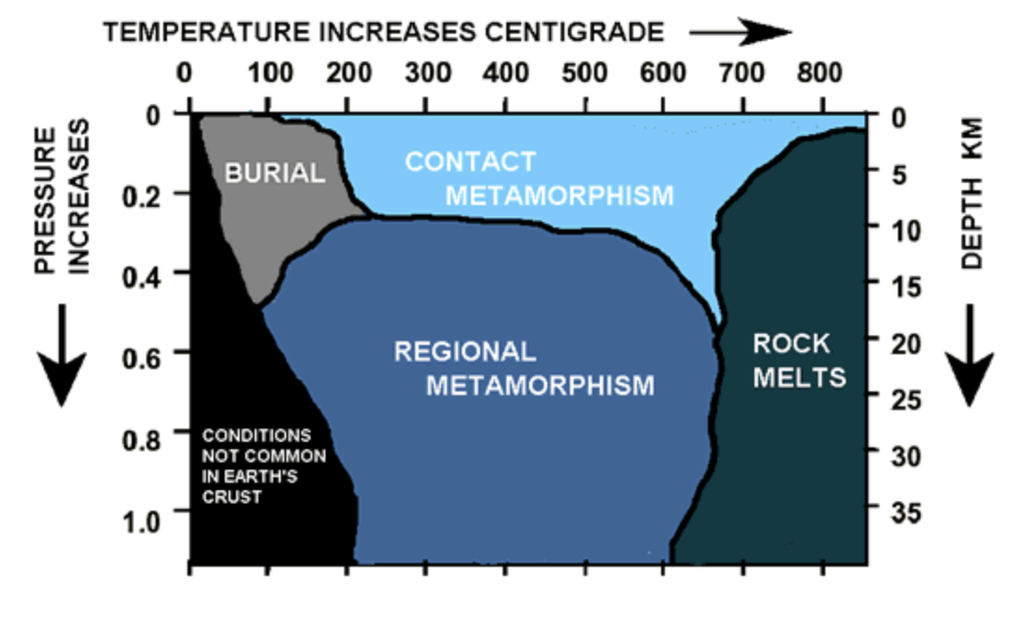

Source: [https://www.msnucleus.org](https://www.msnucleus.org/membership/html/jh/earth/metamorphic/lesson1/metamorphic1g.html)

# Agents of Metamorphism

- **Temperature**: Most common agent; promotes recrystallization.
- **Pressure**: Lithostatic pressure (uniform), or differential stress causing deformation.
- **Nature of the fluid phase**: Promote chemical reactions and transport of ions.
- **State of Stress**: Leads to foliation and lineation.

# Difference Between Pressure and Stress

## Pressure (Lithostatic Pressure)

- **Definition**: A **uniform** force applied in all directions, increasing with depth due to the weight of overlying rocks.
- **Effect**:
  - Promotes the formation of high-density minerals.
  - Causes **recrystallization** but does **not** result in deformation.
  - Rocks remain **unchanged in shape** under pressure.
- **Role in Metamorphism**: Influences mineral stability and density without changing the rock’s structure.

## Stress (Directed or Differential Stress)

- **Definition**: A **directional** force that is stronger in one direction than another, resulting in deformation.
- **Effect**:
  - Causes **deformation** of rocks, changing their shape.
  - Leads to the development of structures like **foliation** and **lineation**.
  - Minerals reorient along planes of weakness due to stress.
- **Role in Metamorphism**: Creates metamorphic **textures** such as foliation and plays a key role in strain (physical deformation).

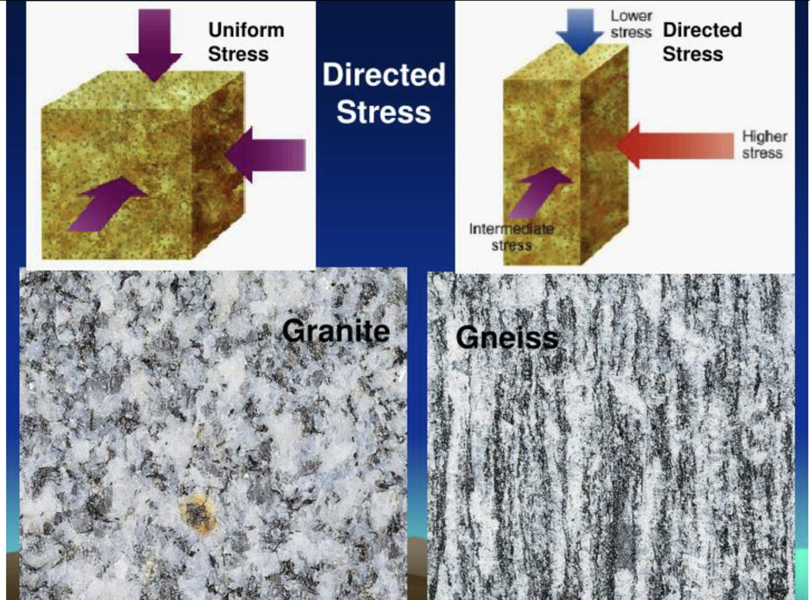

Source: [https://opengeology.org](https://opengeology.org/Mineralogy/8-metamorphic-minerals-and-metamorphic-rocks/)

# Metamorphic Grade

- **Low-Grade Metamorphism**: Fine-grained minerals; minimal recrystallization (e.g., chlorite).
- **High-Grade Metamorphism**: Coarse-grained minerals; extensive recrystallization (e.g., garnet).
- **Indicators**: Mineral assemblages vary based on temperature and pressure conditions.

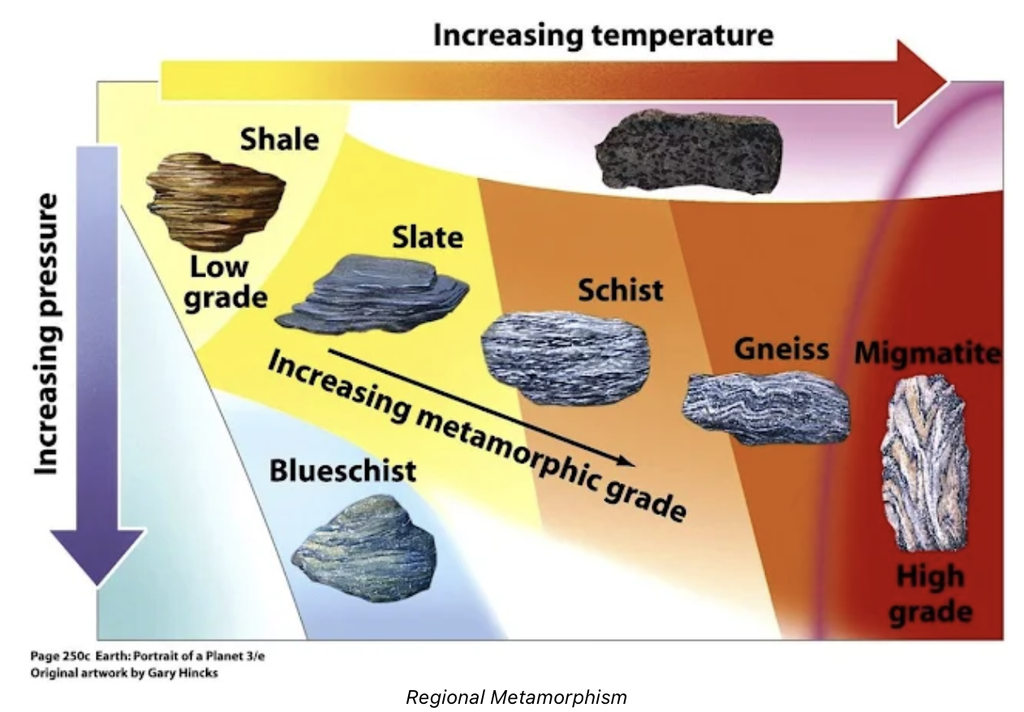

Source: [https://www.geologyin.com/](https://www.geologyin.com/2017/12/regional-metamorphism.html)

# Metamorphic Textures

- **Foliation**: Planar fabric resulting from differential stress (e.g., schist, gneiss).
- **Non-Foliated**: Granoblastic texture in rocks like marble and quartzite.
- **Porphyroblastic**: Large crystals (porphyroblasts) within a finer matrix.

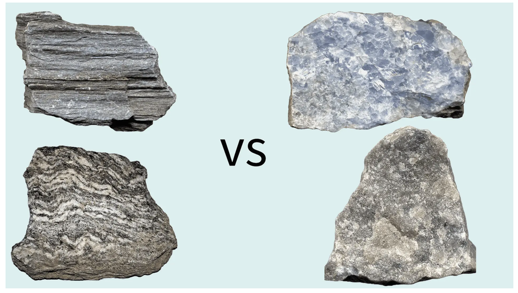

Source: [https://www.zmescience.com/](https://www.zmescience.com/feature-post/natural-sciences/geology-and-paleontology/rocks-and-minerals/metamorphic-rocks/)

# Protoliths and Metamorphic Rocks

- **Recognizing Protoliths**: Mineral assemblages and textures provide clues.
- **Common Metamorphic Rocks**:
  - **Shale** → Slate → Phyllite → Schist → Gneiss (increasing metamorphic grade).
  - **Limestone** → Marble.
  - **Sandstone** → Quartzite.

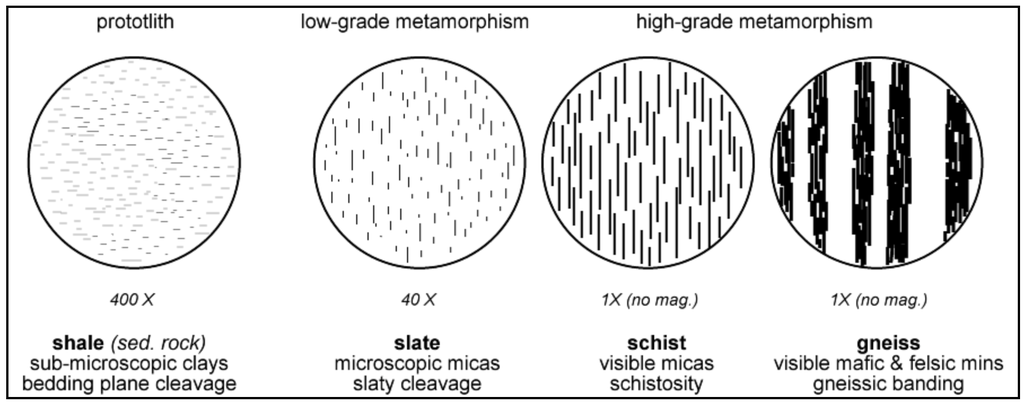

  Source: [https://www.columbia.edu](https://www.columbia.edu/~vjd1/meta_rx.htm)

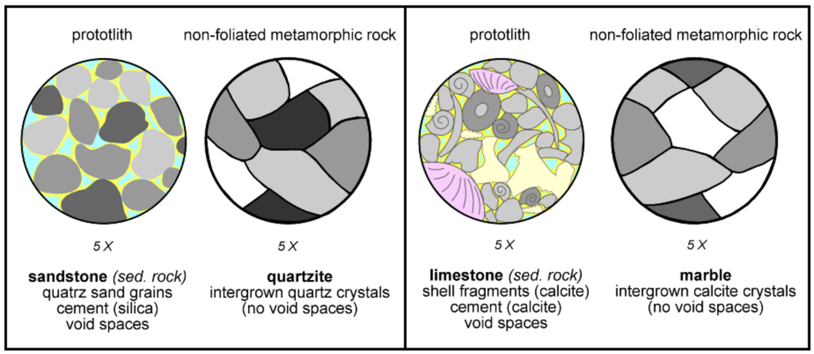

  Source: [https://www.columbia.edu](https://www.columbia.edu/~vjd1/meta_rx.htm)

# Field Settings of Metamorphism

- **Orogenic Belts**: Regional metamorphism with high-pressure, low-temperature conditions.
- **Subduction Zones**: Blueschist and eclogite facies, high-pressure, low-temperature rocks.
- **Contact Aureoles**: Localized heating around magmatic intrusions.

# Metamorphic Reactions

- **Recrystallization**: Formation of new minerals without melting.
- **Devolatilization**: Release of water or CO2 during the breakdown of hydrous or carbonate minerals.

# Summary of Key Points

- Metamorphism occurs due to heat, pressure, fluids, and stress.
- It results in new minerals, textures, and rock types.
- Field settings like orogenic belts and subduction zones show distinct metamorphic facies.
- Recognizing protoliths and studying textures helps understand metamorphic processes.